# Project 2032

Confronting the Facts

09/08/2021

#### Data Exploration

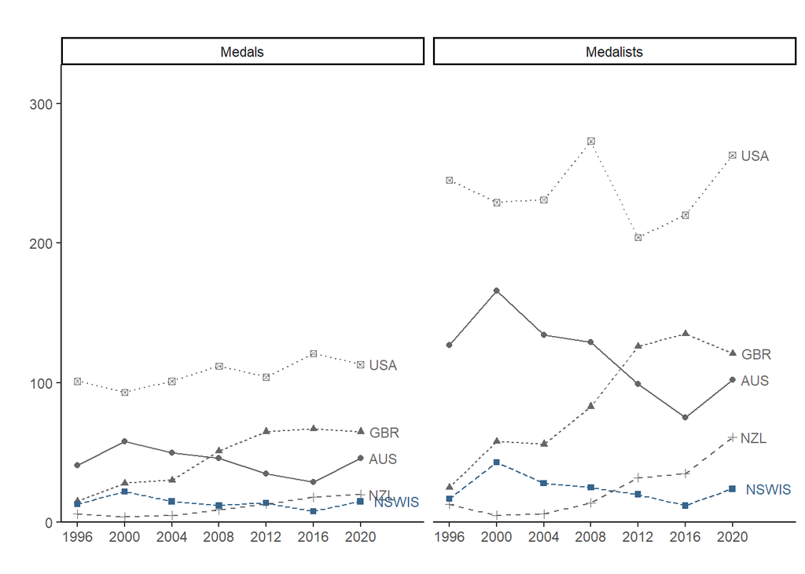

- AUS medals and medalists declined between 2000 and 2016, while USA, GBR and NZL increased
- NZL have closed the gap between themselves and AUS

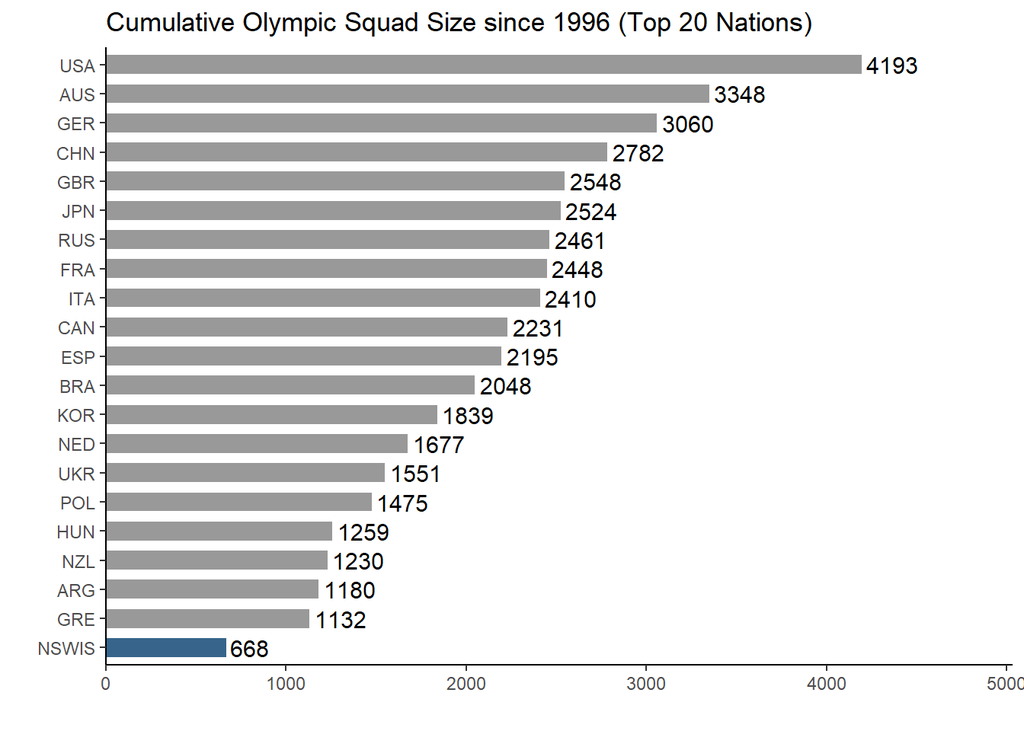

- The cumulative squad size for AUS between 1996 and 2020 is second only to USA
- AUS have sent a lot of athletes to the Games

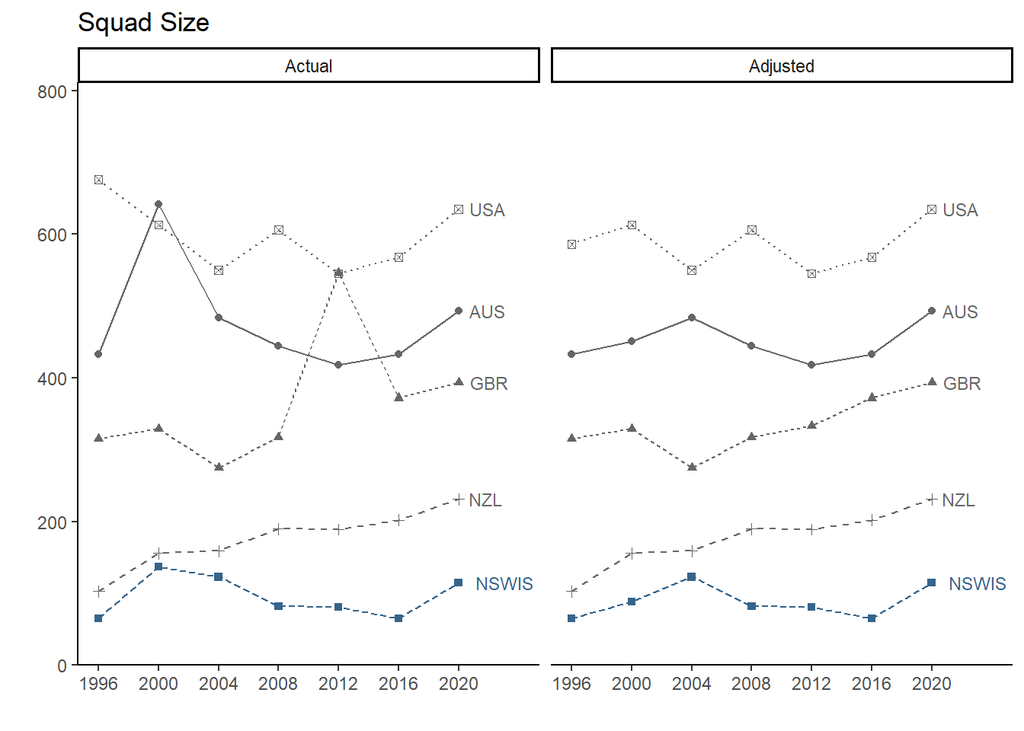

- Outside of cases where the nation hosted the Games, squad sizes have remained somewhat consistent with minor fluctations each cycle.
- There may be a hint of a steady rise in squad size for GBR and NZL since 2004.
- Relative to other countries, again AUS are sending a lot of athletes to the Games.

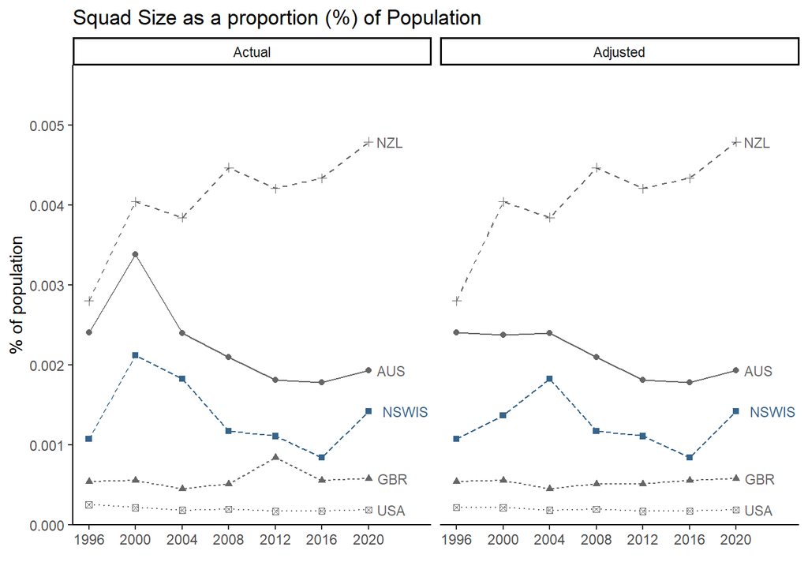

- Relative to population size, AUS has a large Olympic squad size
- In relation to population size, AUS’s Olympic squad size declined between 2004 and 2016

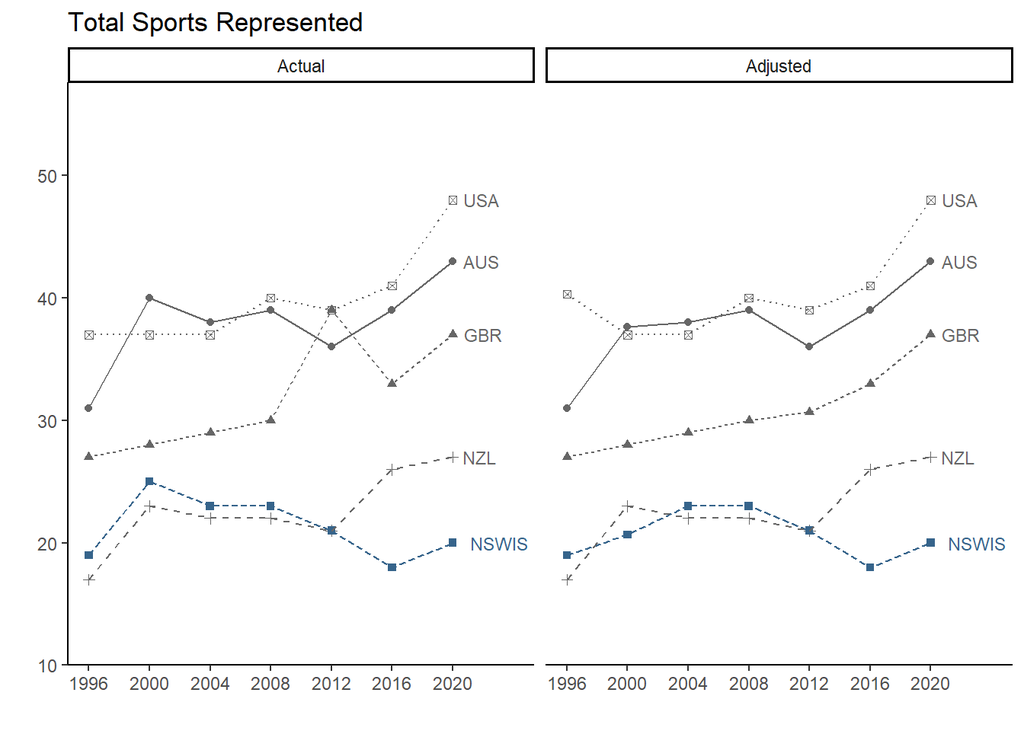

- Australia has historically competed in a relatively high number of different sports.
- Between 2000 and 2016, the number of different sports was quite steady for AUS.
- GBR have gradually increased the number of sports they competed in.

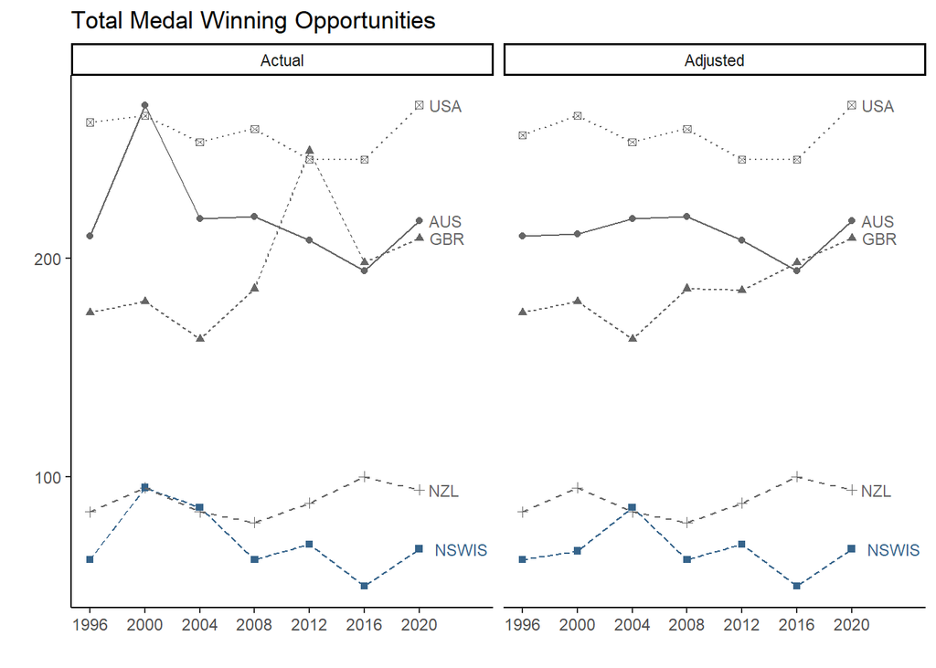

- The number of medal winning opportunities for AUS in 2016 reduced by 28% from 2000 (49% for NSWIS!).
- This is despite a consistently large squad size and spread of sports

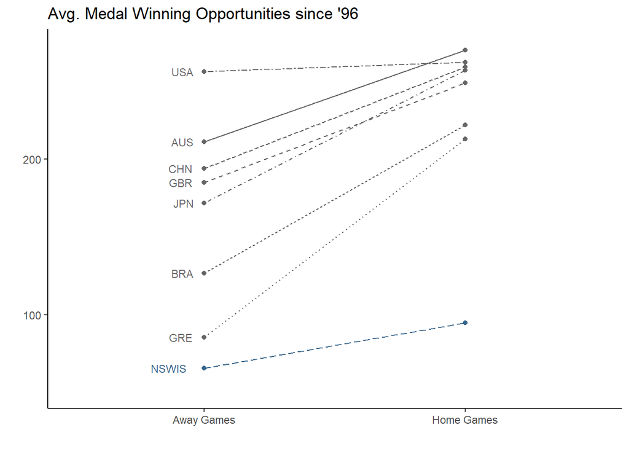

- Historically, a home Games provides more Medal Winning Opportunities (USA is an exception)
- On average, since 1996 the host nation has had **51.8% more medal winning opportunities** than they had at other Games!

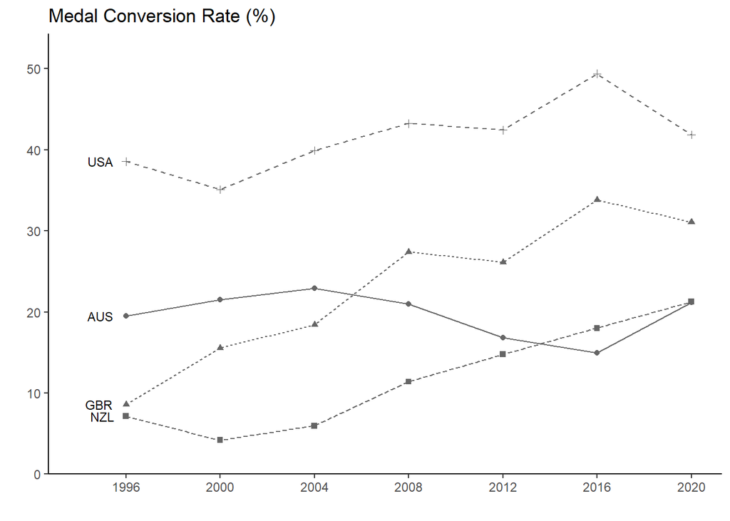

- Medal conversion rate decreased from a peak of 22.9% in Athens, to 14.9% in Rio
- The reduction in total medals for AUS between 2000 and 2016 is attributed to *both* a decrease in medal-winning opportunities *and* a decrease in medal conversion rate.

`Total Medals = Medal Opportunities x Medal Conversion`

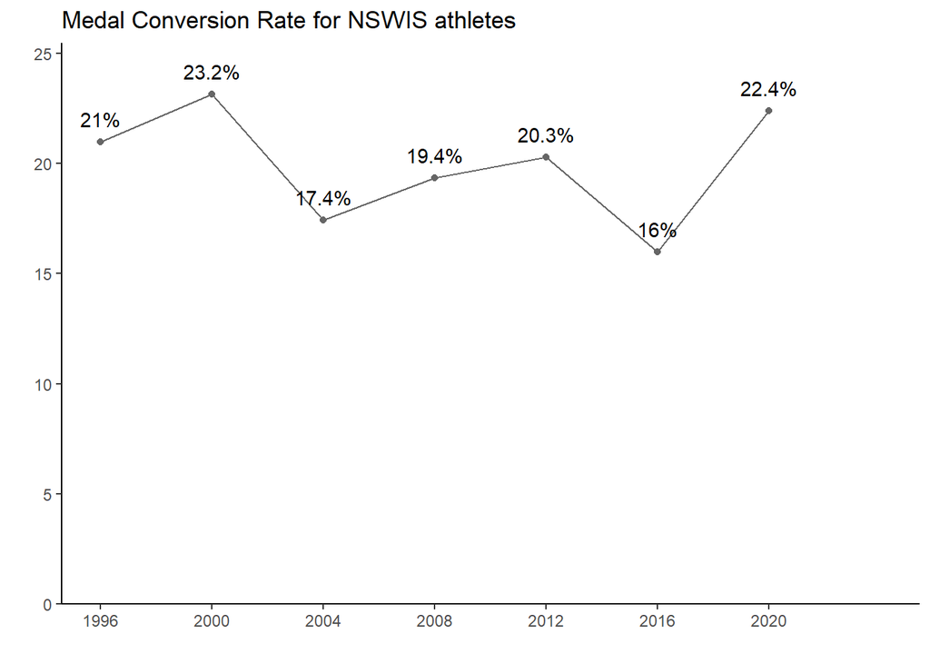

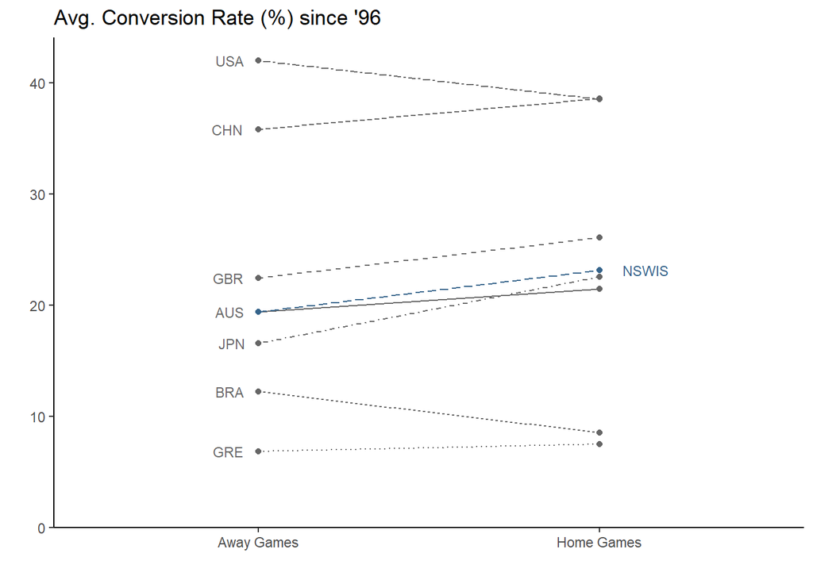

- There is no significant change in Medal Conversion Rate between a home Games and an away Games (average of 1.4% increase for home Games)
- Any increase in medal count at a home Games is most likely attributed to a higher number of Medal Winning Opportunities, not conversion rate

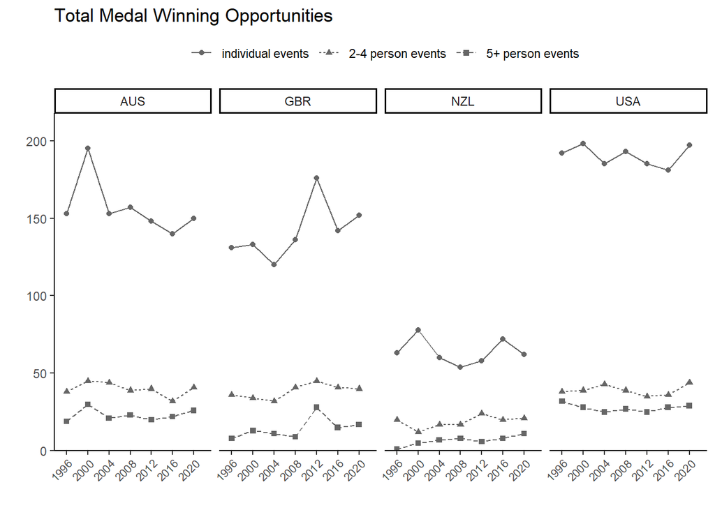

- Specifically, a reduction in medal winning opportunities for AUS is evident in individual events.
- Medal winning opportunities for AUS in individual events has been relatively high

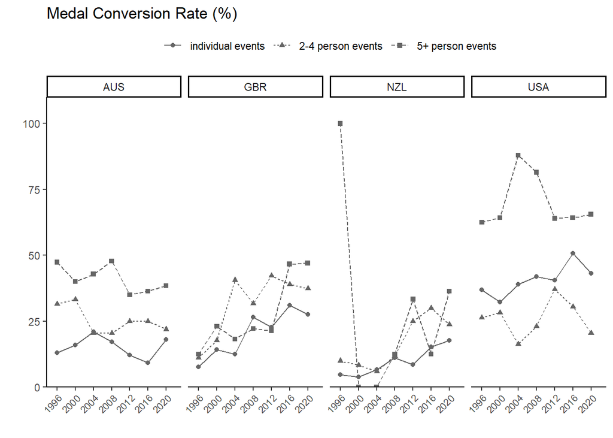

- Looking at the medal conversion rate for individual events, AUS is on a downward trajectory, while GBR, NZL and USA are on an upward trajectory.

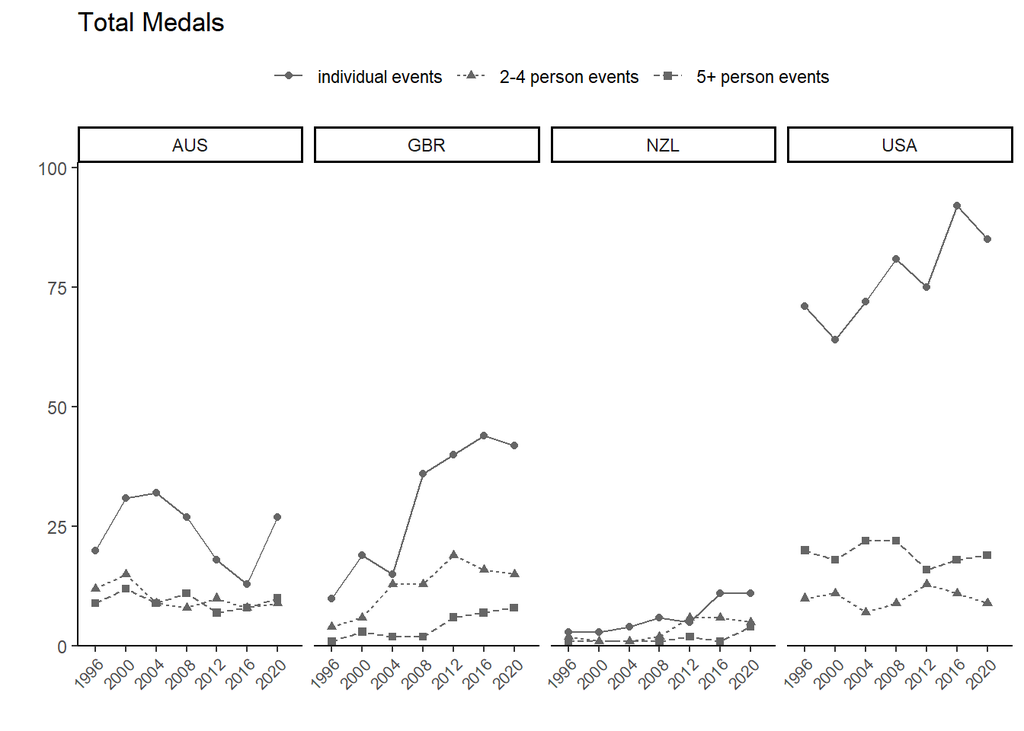

- When looking at number of medals in individual events, AUS clearly declined between 2004 and 2016, while GBR, NZL and USA generally improved.
- USA wins significantly more medals in individual events compared to other nations

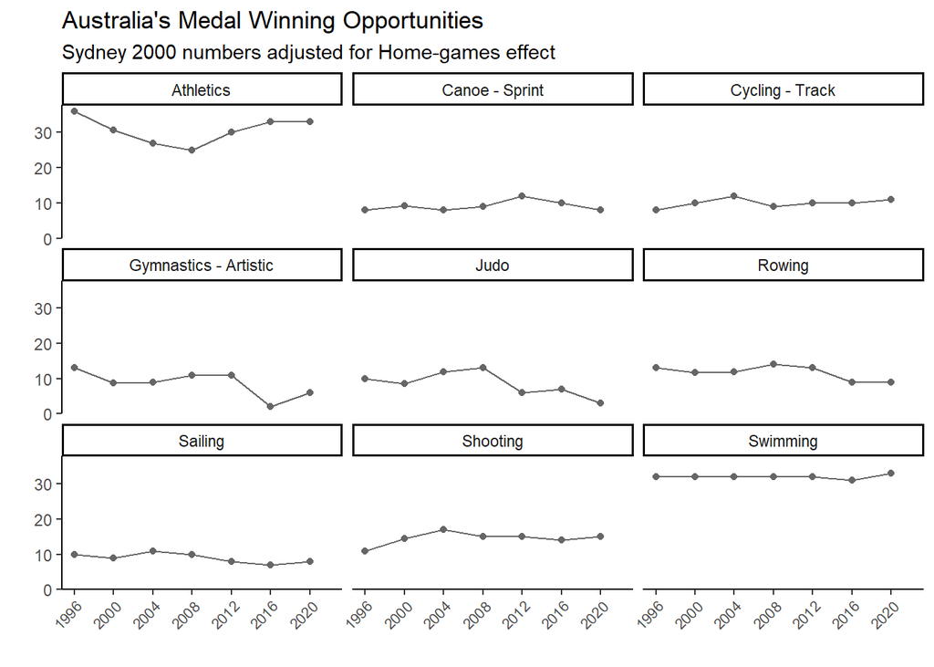

- Athletics and Swimming have provided AUS with the highest number of medal winning opportunities

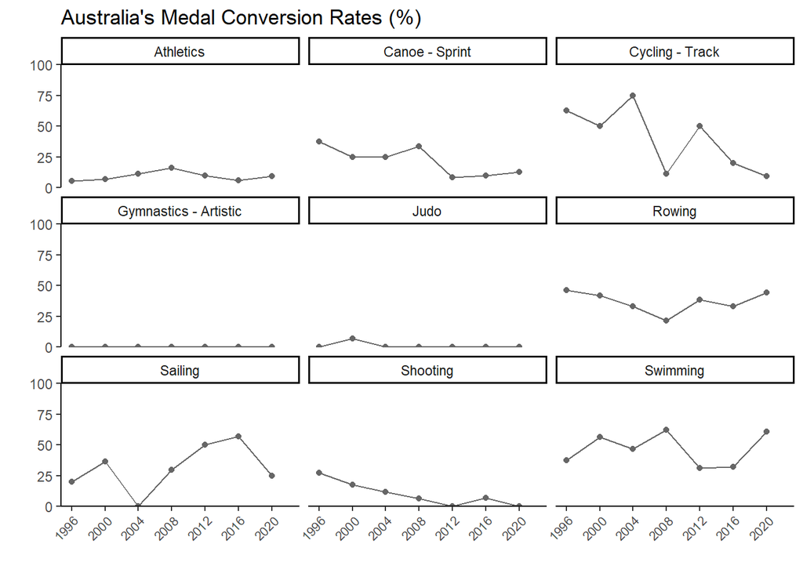

- Medal conversion rate in Athletics is typically low for AUS
- Medal conversion rate in Swimming was 62.5% in Beijing and 60% in Tokyo
- Some sports are steady over time, and others fluctuate

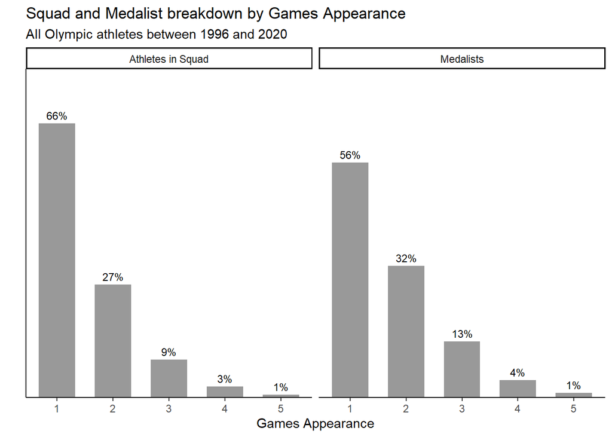

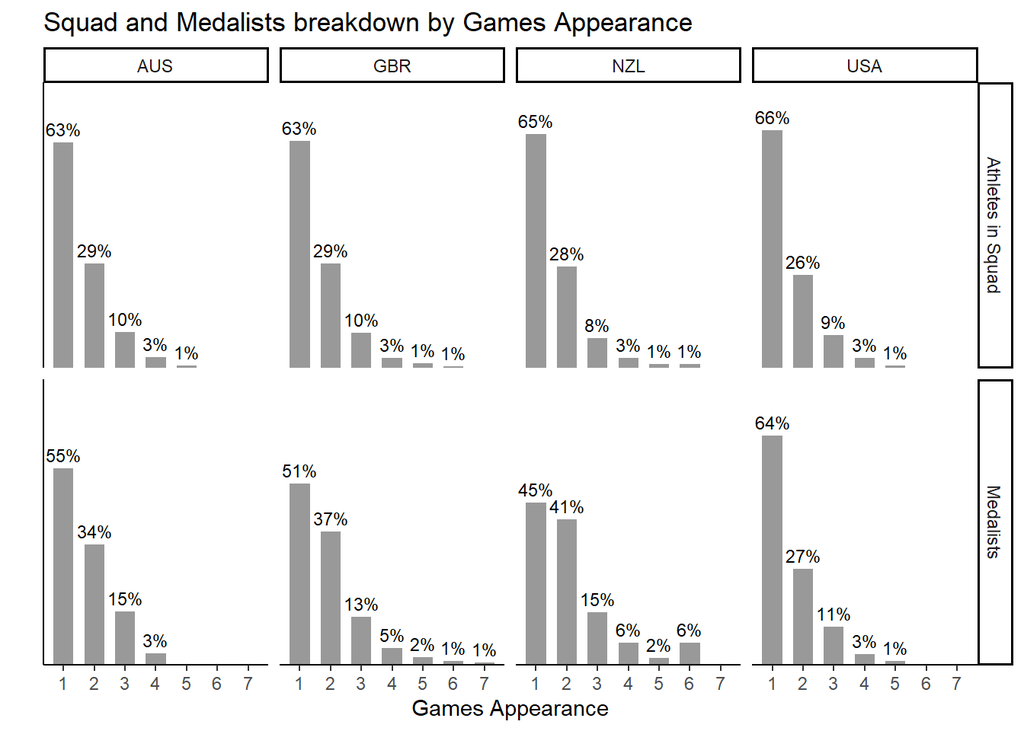

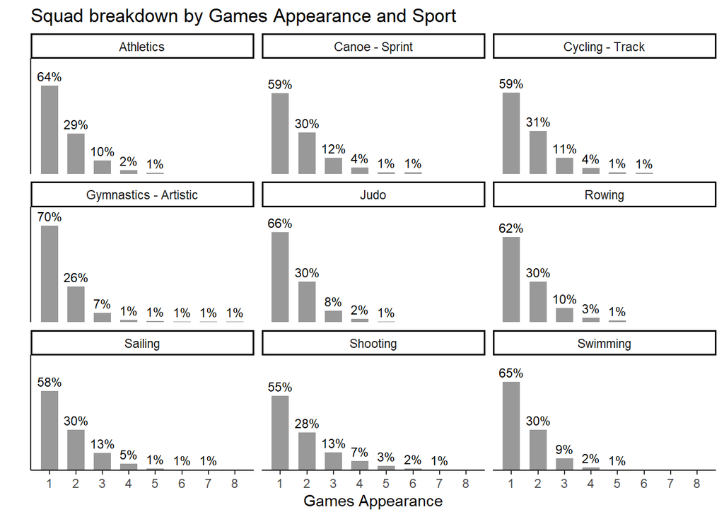

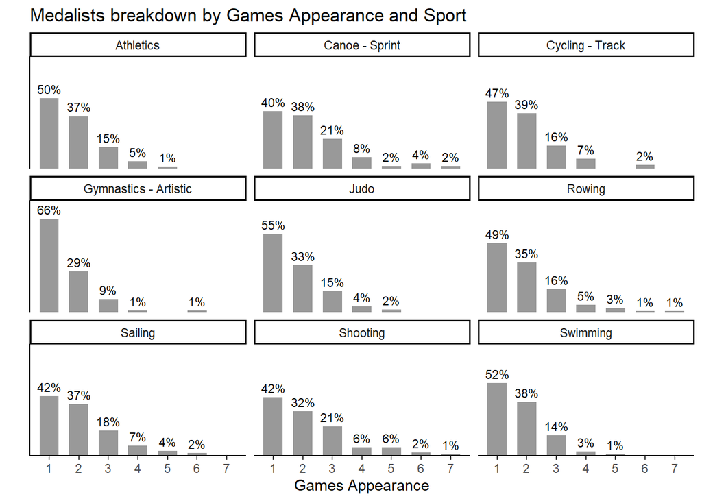

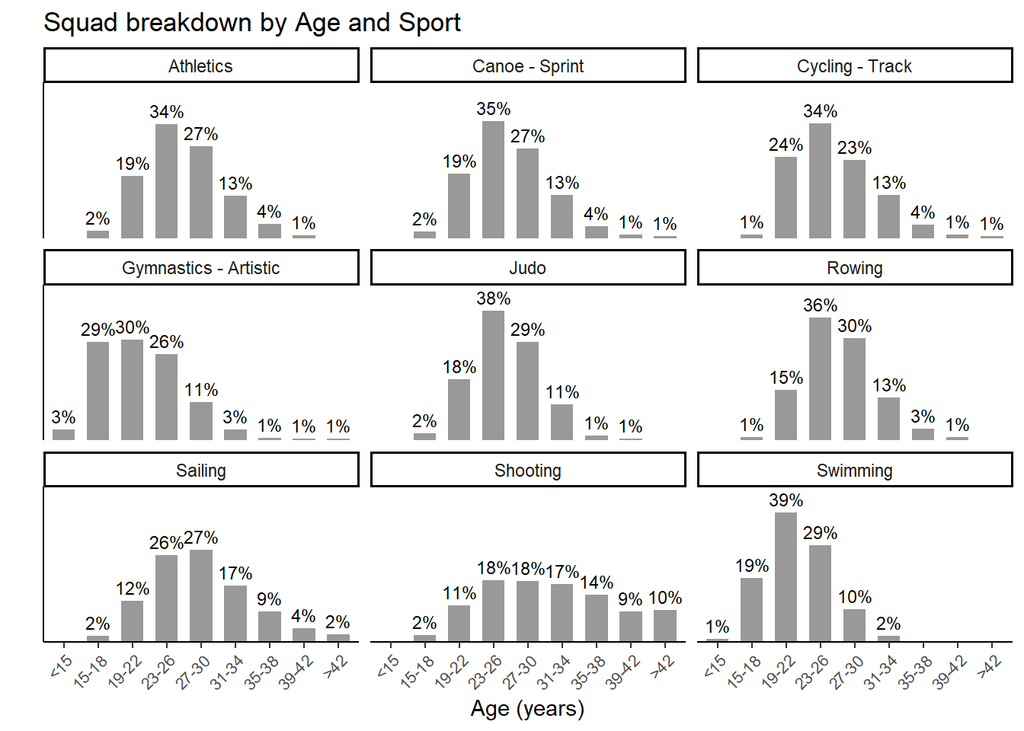

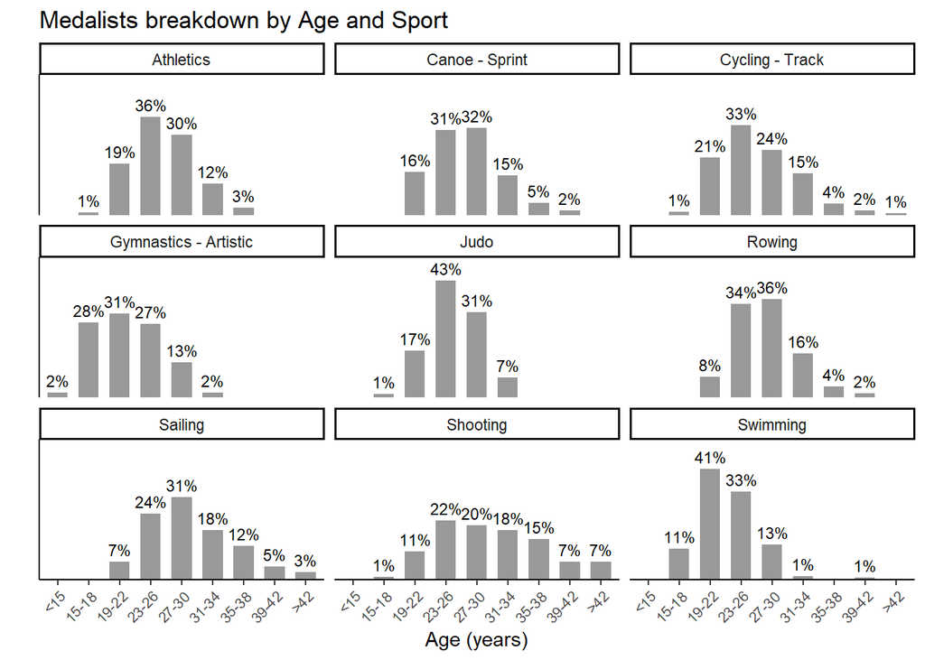